# Economia Regional

João Vitor da Silva Santos

2024-11-17

# Rodovias Federais

## BR - 101

> - Extensão: Aproximadamente 4.772 km.
> - Trajeto: Liga o extremo norte (Touros, RN) ao extremo sul (São José do Norte, RS).
> - Importância: É a maior rodovia do país e percorre quase toda a costa brasileira, conectando várias capitais, como Natal, Recife, Salvador, e Florianópolis.

[figure not shown]

### Condições da BR - 101

O trecho da BR-101 em Santa Catarina, especialmente entre Itapema e Navegantes, enfrenta severo congestionamento, afetando a mobilidade e a economia, que depende fortemente da rodovia para escoar produtos e atender ao turismo. Problemas como crescimento urbano desordenado, aumento no tráfego portuário e turístico, e infraestrutura limitada resultam em longos tempos de viagem e prejuízos econômicos.

A Fiesc propõe prorrogar a concessão rodoviária e investir R$ 8,59 bilhões em melhorias, mas uma solução definitiva seria a construção de uma rodovia paralela, estimada em R$ 9,2 bilhões, cuja conclusão só seria viável por volta de 2033.

Medidas emergenciais incluem o uso do acostamento em horários críticos e a ideia de pedágios variáveis para gerenciar o fluxo. A entrega recente de um contorno viário em Florianópolis ajudou a aliviar parte do trânsito, mas os gargalos persistem em outras regiões.

Enquanto o governo e empresários discutem soluções, a situação segue desafiadora, afetando tanto o transporte de cargas quanto o turismo no estado.

## BR - 116

[figure not shown]

### Condições da BR - 116

O trecho da **BR-116 em Muriaé, MG**, entre os km 700 e 710, está entre os 10 mais perigosos das rodovias federais em Minas Gerais, com **92 acidentes e 2 mortes** registrados entre novembro de 2022 e novembro de 2023, segundo levantamento da CNT. Um dos acidentes mais graves foi uma colisão entre duas carretas em outubro, que resultou na morte de um motorista.

Desde que a EcoRioMinas assumiu a administração da rodovia em setembro de 2022, melhorias iniciais foram realizadas para aumentar a segurança. A concessionária está reimplantando radares removidos pelo DNIT e planeja instalar **seis novos radares e faixas adicionais** entre os km 610 e 620.

No estado, a **colisão é a principal causa de acidentes**, que totalizaram **8.814 ocorrências e 712 mortes** no período analisado. Outras causas incluem saídas de pista, capotamentos e atropelamentos.

Entre os trechos mais críticos de Minas, a **BR-381**, na região metropolitana de Belo Horizonte, lidera em número de acidentes, seguida pela **BR-040**. A pesquisa da CNT também destacou a **BR-116 entre Valadares e Além Paraíba** como a melhor estrada da região, enquanto a pior é a **MG-482, que liga Conselheiro Lafaiete a Viçosa**.

## BR - 070

> - Extensão: Aproximadamente 1.900 km.
> - Trajeto: Liga Brasília (DF) a Cáceres (MT).
> - Importância: É estratégica para o transporte entre o Centro-Oeste e o restante do país.

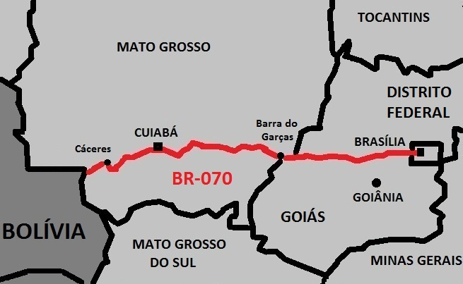

### Condições da BR - 070

As melhorias, que contarão com um investimento de aproximadamente R$ 50,6 milhões, estão incluídas no Novo Programa de Aceleração do Crescimento (Novo PAC). O contrato prevê, além da pavimentação, drenagem, terraplanagem e a construção de Obras de Arte Especiais (OAE).

As Obras de Arte Especiais são obras que exigem projeto e execução específicos para superar obstáculos naturais ou artificiais, e assim garantir a segurança e a eficiência do trânsito. Como por exemplo, pontes, viadutos e túneis. No contexto da BR-070/GO, as OAEs podem incluir a construção de pontes sobre rios ou viadutos que permitam a travessia de áreas com desníveis acentuados, garantindo assim a continuidade e a qualidade da via pavimentada, melhorando as condições de tráfego, especialmente durante a temporada de chuvas.

A BR-070 é uma das principais rodovias radiais do Brasil, começando no Distrito Federal, passando por Goiás e terminando em Cáceres, no Mato Grosso. A melhoria da infraestrutura rodoviária facilita o escoamento da produção do agronegócio no estado de Goiás. A pavimentação da rodovia ainda vai trazer impacto socioeconômico para a região de Itaguari, conhecida nacionalmente por sua crescente indústria de moda íntima. A expectativa é a geração de novos empregos e um impulso na economia local.

## BR - 230

> - Extensão: Aproximadamente 4.223 km.
> - Trajeto: Liga Cabedelo (PB) a Lábrea (AM).
> - Importância: Conhecida como Transamazônica, é fundamental para a integração da região Norte.

[figure not shown]

### Condições da BR - 230

A **BR-230**, ou **Rodovia Transamazônica**, completou 50 anos em 2022 e é uma das principais rodovias do Brasil, ligando as regiões **Norte e Nordeste**. Inaugurada em 27 de agosto de 1972, a rodovia possui **4.260 km** construídos, conectando **Cabedelo (PB)** a **Lábrea (AM)**. Embora o projeto original previa **8 mil km**, apenas parte foi concluída, com vários trechos ainda sem pavimentação.

Embora inacabada, a rodovia é um eixo estratégico para transporte e desenvolvimento nas regiões que atravessa.

## BR - 381

> - Extensão: Aproximadamente 1.200 km.
> - Trajeto: Liga São Mateus (ES) a São Paulo (SP).
> - Importância: Conhecida como Rodovia Fernão Dias, conecta Belo Horizonte a São Paulo, sendo vital para o transporte no Sudeste.

[figure not shown]

### Condições da BR - 381

A concessão da BR-381/MG marca um avanço significativo na infraestrutura rodoviária do Brasil. Este leilão, vencido pela 4UM FIP em Infraestrutura de Responsabilidade Ltda., representa a solução de um problema histórico, garantindo investimentos expressivos na ordem de **R$ 9,34 bilhões** e o compromisso de transformar a rodovia em um modelo de segurança e eficiência.

#### Pontos principais do projeto:

1. **Extensão e Impacto**:
   - Abrange **296,3 km** entre Belo Horizonte e Governador Valadares.
   - Envolve 13 cidades diretamente e beneficia cerca de **3,7 milhões de pessoas**.
   - Média de tráfego diário de **24.733 veículos**.
2. **Obras e Melhorias Previstas**:
   - **Duplicação de 106 km**.
   - **83 km de faixas adicionais** e **51 correções de traçado**.
   - Construção de **23 passarelas**, **áreas de escape**, e Pontos de Parada e Descanso (PPD).
   - Modernização de sinalização e implementação de Bases de Serviço Operacional (BSO).
3. **Calendário de Execução**:
   - Contrato será assinado em **28 de novembro de 2024**.
   - Obras iniciais (recuperação e sinalização): **primeiro ano**.
   - Duplicação: **quarto ao sétimo ano**.
   - Faixas adicionais: **sexto ao oitavo ano**.
   - Manutenção contínua nos anos subsequentes.
4. **Tarifas e Descontos**:
   - Tarifa inicial de pedágio com desconto de **0,94%**.
   - Incentivos para usuários frequentes e redução de **5% para pagamento eletrônico**.
5. **Histórico e Ajustes**:
   - Após tentativas anteriores falhas, o projeto foi remodelado com:
     - Redução de valores de Capex e Opex.
     - Inclusão de critérios de menor tarifa e maior aporte proporcional.
     - Decisão do governo federal de assumir obras em trechos específicos.
6. **Impacto Econômico**:
   - Estima-se a geração de **80.879 empregos diretos e indiretos**.
   - Benefícios logísticos para o escoamento de produtos industriais, especialmente no Vale do Aço.

A iniciativa, que teve apoio do governo federal, estadual e de entidades como a ANTT, reafirma o compromisso com o desenvolvimento de infraestrutura no Brasil, possibilitando melhores condições de trafegabilidade e impulsionando o crescimento econômico regional.

## Malha Paulista

> - Extensão: Aproximadamente 2.000 km.
> - Trajeto: Abrange o estado de São Paulo e conecta-se a outras malhas ferroviárias e portos, como o de Santos.
> - Importância: É um dos principais eixos ferroviários do país, movimentando produtos agrícolas e industriais.

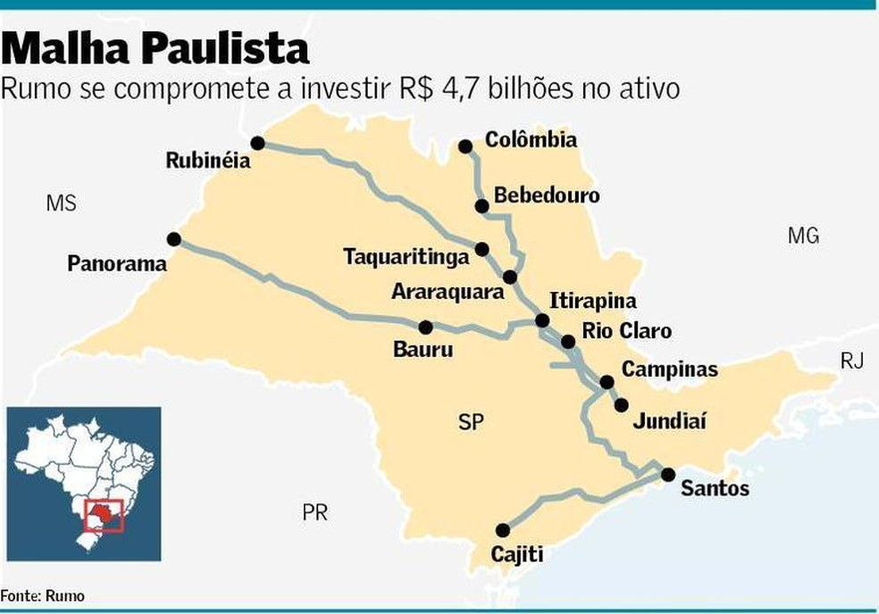

## Transnordestina

> - Extensão: Prevista para 1.753 km.
> - Trajeto: Conectará Eliseu Martins (PI) aos portos de Pecém (CE) e Suape (PE).
> - Importância: Estratégica para o desenvolvimento do Nordeste, facilitando o transporte de grãos, minério e combustíveis.

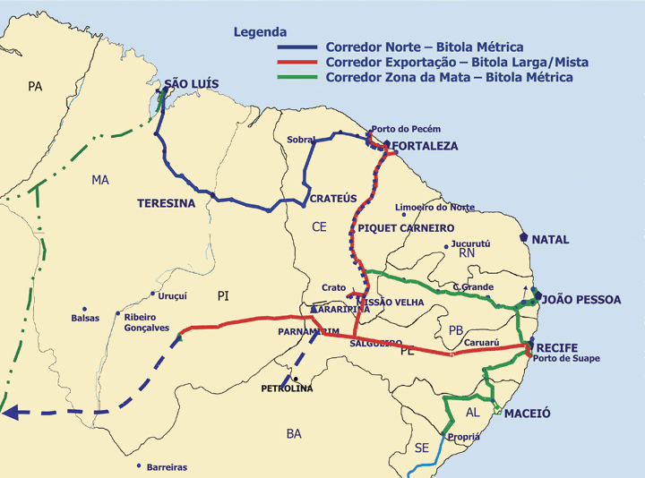

## FIOL - Ferrovia de Integração Oeste - Leste

Com aproximadamente 1527 km de extensão, a Ferrovia de Integração Oeste Leste-FIOL ligará o futuro porto de Ilhéus (no litoral baiano) a Figueirópolis (em Tocantins), ponto em que se conectará com a Ferrovia Norte Sul.

### Objetivos

- Estabelecer alternativas mais econômicas para os fluxos de carga de longa distância;
- Favorecer a multimodalidade;
- Interligar a malha ferroviária brasileira;
- Propor nova alternativa logística para o escoamento da produção agrícola e de mineração por meio do terminal portuário de Ilhéus/BA; e
- Incentivar investimentos, para incrementar a produção e induzir a processos produtivos modernos.

### Benefícios

- Reduzir os custos de transporte de grãos, álcool e minérios destinados aos mercados
- internos e externos;
- Aumentar a produção agroindustrial da região, motivada por melhores condições de acesso aos mercados nacional e internacional;
- Interligar os estados de Tocantins, Maranhão, Goiás e Bahia aos portos de Ilhéus/BA e
- Itaqui/MA, o que proporcionará melhor desempenho econômico de toda a malha ferroviária;
- Incentivar os investimentos, a modernização e a produção;
- Melhorar a renda e a distribuição da riqueza nacional;
- Reduzir a emissão de poluentes;
- Reduzir o número de acidentes em rodovias.

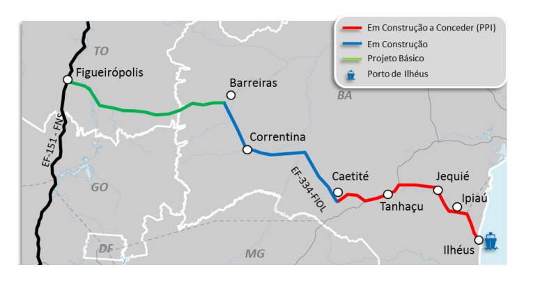

# Infraestrutura logística e redução das desigualdades regionais

## Integração das regiões:

> - Conexão entre mercados locais e nacionais
> - Acesso a insumos e tecnologia

## Atração de investimentos e desenvolvimento econômico:

> - Estimulação da industrialização
> - Crescimento de polos econômicos regionais

## Geração de empregos locais

## Redução do custo de vida e melhoria da qualidade de vida

## Descentralização econômica

https://www.gov.br/transportes/pt-br/assuntos/noticias/2024/11/com-obras-avancadas-e-financiamento-garantido-transnordestina-devera-ser-entregue-em-2026-1